# Distrito Capital. Dinamica. Exploraciones

```r
load("D:/clasesInsumos/clases2016I/dtoCapital/dinamicaDs.RData")
```

```r
head(dinamica1Totales)
```

| parroquia | 2001 | 2002 | 2003 | 2004 | 2005 | 2006 | 2007 | 2008 | 2009 | 2010 | 2011 | 2012 |
| --- | --- | --- | --- | --- | --- | --- | --- | --- | --- | --- | --- | --- |
| Altagracia | 1008 | 771 | 898 | 918 | 958 | 1078 | 897 | 960 | 711 | 725 | 613 | 567 |
| Antímano | 2711 | 2882 | 4024 | 3995 | 4033 | 3689 | 3951 | 3968 | 3853 | 3907 | 3491 | 3220 |
| Candelaria | 621 | 437 | 689 | 706 | 834 | 861 | 714 | 660 | 646 | 729 | 785 | 709 |
| Caricuao | 1643 | 1576 | 2274 | 2561 | 2845 | 2680 | 2692 | 2183 | 2374 | 2222 | 2218 | 2096 |
| Catedral | 292 | 278 | 229 | 173 | 168 | 140 | 172 | 142 | 150 | 113 | 170 | 170 |
| Coche | 973 | 749 | 987 | 932 | 817 | 1037 | 1094 | 879 | 1025 | 1062 | 1255 | 1227 |

```r
# creo una funcion propia para calcular la tas de variacion

variacion1<-function(x, y){
# obtener la tasa de crecimieto  o decrecimiento de una variabe
# x: anio mas reciente
# y: anio inicial
# formula (x-y)/y *100
# aplicacion:  variacion1(empleo1976, empleo1965)
        diferencia <- x-y
        cociente <-diferencia/y
        tasa <- round(cociente*100, 2)
        return(tasa)
}
```

Si la funcion ha sido programada correctamente el resultado debe ser

```r
# pruebo la funcion
(dinamica1Totales$`2012`-dinamica1Totales$`2001`)/dinamica1Totales$`2001`*100
```

```
 [1] -43.750000  18.775360  14.170692  27.571516 -41.780822  26.104830
 [7]  99.786553   9.822264  18.423645 -10.296462  -2.578269  25.347044
[13] -28.217822 -26.071842 122.246456  10.611511  26.251823  19.968304
[19]  69.360902  27.516779  36.424709  -3.980892
```

Pruebo la funcion

```r
variacion1(dinamica1Totales$`2012`, dinamica1Totales$`2001`)
```

```
 [1] -43.75  18.78  14.17  27.57 -41.78  26.10  99.79   9.82  18.42 -10.30
[11]  -2.58  25.35 -28.22 -26.07 122.25  10.61  26.25  19.97  69.36  27.52
[21]  36.42  -3.98
```

Creo un marco de datos para revisar la variacion en los nacimientos en las distintas parroquias del Distrito Capital, segúnresdiencia ahbitual de la madre.

Recordando la fórmula

$$variacion\ =\ \frac{\left(valor\ reciente\ -\ valor\ inicial\right)}{valor\ inicial}\cdot100\$$

```r
variacion1(dinamica1Totales$`2012`, dinamica1Totales$`2001`)
```

```
 [1] -43.75  18.78  14.17  27.57 -41.78  26.10  99.79   9.82  18.42 -10.30
[11]  -2.58  25.35 -28.22 -26.07 122.25  10.61  26.25  19.97  69.36  27.52
[21]  36.42  -3.98
```

```r
# analizo los nacimientos vivos por parroquia en
# distrito capital entre 2001 y 2012

nacimiento_parroquia <- data.frame(
        parroquia = dinamica1Totales$parroquia,
        variacion = variacion1(dinamica1Totales$`2012`,
                               dinamica1Totales$`2001`)
)

# exploro mi marco de datos
nacimiento_parroquia
```

| parroquia | variacion |
| --- | --- |
| Altagracia | -43.75 |
| Antímano | 18.78 |
| Candelaria | 14.17 |
| Caricuao | 27.57 |
| Catedral | -41.78 |
| Coche | 26.10 |
| El Junquito | 99.79 |
| El Paraíso | 9.82 |
| El Recreo | 18.42 |
| El Valle | -10.30 |

[output cut: 12 more lines]

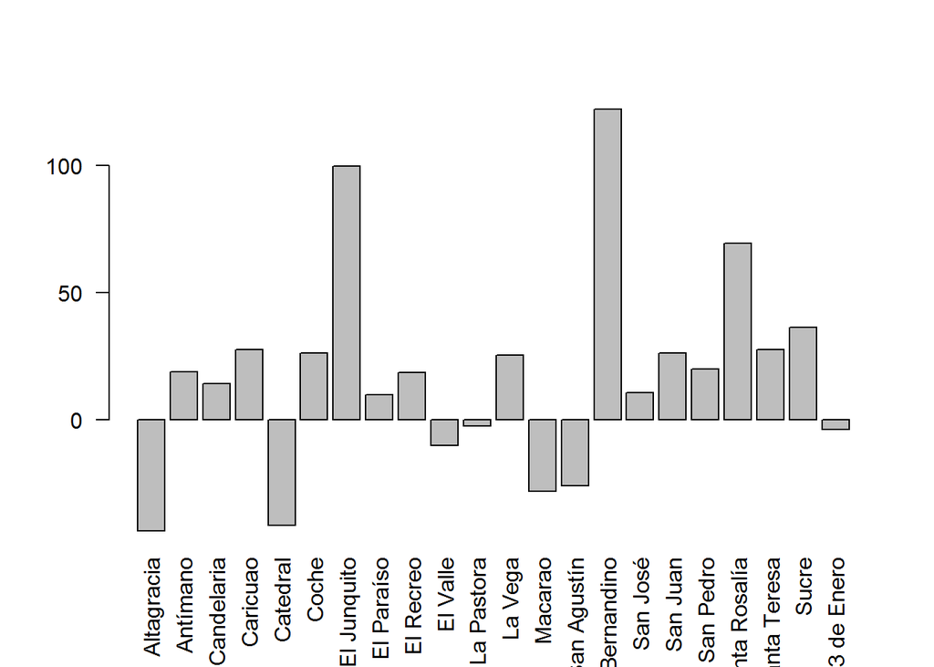

```r
barplot(nacimiento_parroquia[,2],
        names.arg = nacimiento_parroquia[,1],
        las=2)
```

En general, el número de nacimientos ha disminuidos en las parroquias que se formaron primero en el Distrito Capital, bien a finales del siglo XIX o a principios del siglo XX: Catedral, Altagracia, por ejemplo. Ese fenómenos posiblemente se debe al hecho de que los urbanismos se han desarrollado fuera de estos lugares y quienes habitan allí suelen ser personas de mayor edad. Algunas de las parroquias históricas como Santa teresa, San Bernardino y Santa Rosalía, muestra un incremento en el número de nacimientos, tal vez como resultado de las edificaciones nuevas construídas allí en el marco de la Misión Vivienda.

Para tratar de corroborar esto, sería necesario examinar la pobación intercensal en estas parroquias. Dado que estos datos son producto de, posiblmente, la interpolación del número de nacimientos entre los censos del 2001 y el censod de 2011.

Examino la evolución del índice de masculinidad. Primero exploro el marco de datos que cree sobre los nacimientos vivos en Distrito Capital, según la parroquia de residencia de la madre

```r
head(dinamica1Sexo)
```

| parroquia | H2001 | M2001 | H2002 | M2002 | H2003 | M2003 | H2004 | M2004 | H2005 | M2005 | H2006 | M2006 | H2007 | M2007 | H2008 | M2008 | H2009 | M2009 | H2010 | M2010 | H2011 | M2011 | H2012 | M2012 |
| --- | --- | --- | --- | --- | --- | --- | --- | --- | --- | --- | --- | --- | --- | --- | --- | --- | --- | --- | --- | --- | --- | --- | --- | --- |
| Altagracia | 541 | 467 | 397 | 374 | 486 | 412 | 495 | 423 | 496 | 462 | 539 | 539 | 458 | 439 | 490 | 470 | 364 | 347 | 368 | 357 | 301 | 312 | 275 | 292 |
| Antímano | 1384 | 1327 | 1522 | 1360 | 2089 | 1935 | 2053 | 1942 | 2046 | 1987 | 1886 | 1803 | 2038 | 1913 | 2033 | 1935 | 1962 | 1891 | 2020 | 1887 | 1744 | 1747 | 1613 | 1607 |
| Candelaria | 331 | 290 | 254 | 183 | 370 | 319 | 391 | 315 | 423 | 411 | 453 | 408 | 354 | 360 | 321 | 339 | 340 | 306 | 377 | 352 | 423 | 362 | 385 | 324 |
| Caricuao | 836 | 807 | 850 | 726 | 1172 | 1102 | 1280 | 1281 | 1453 | 1392 | 1339 | 1341 | 1385 | 1307 | 1133 | 1050 | 1234 | 1140 | 1138 | 1084 | 1116 | 1102 | 1118 | 978 |
| Catedral | 146 | 146 | 148 | 130 | 114 | 115 | 75 | 98 | 87 | 81 | 66 | 74 | 92 | 80 | 70 | 72 | 73 | 77 | 56 | 57 | 87 | 83 | 89 | 81 |
| Coche | 491 | 482 | 404 | 345 | 511 | 476 | 501 | 431 | 419 | 398 | 550 | 487 | 540 | 554 | 442 | 437 | 526 | 499 | 555 | 507 | 652 | 603 | 616 | 611 |

Construyo una función que me permita analizar rápidamente el índice de masculinidad. La fórmula es

$$masculinidad=100\cdot\frac{Hombres}{Mujeres}$$

```r
masculinidad <-function(hombres, mujeres){
# obtener el indice de masculinidad
# hombres: vector con el numero de hombres
# mujeres: vector con el numero de mujeres
# formula: hombres/mujeres * 100
# aplicacion:  masculinidad(hombres_en, mujeres_en)
        indices <- round(100*hombres/mujeres,2)
        return(indices)

}
```

Pruebo la funcion

```r
# sin aplicar la funcion
dinamica1Sexo$H2001/dinamica1Sexo$M2001 *100
```

```
 [1] 115.84582 104.29540 114.13793 103.59356 100.00000 101.86722  93.99586
 [8] 110.43307 113.68421 115.01028  96.38336 122.54005 109.17160 119.03553
[15] 124.75490 105.92593 114.04787 109.63455 101.51515 115.94203 111.61581
[22] 115.43739
```

```r
# con la funcion masculinidad
masculinidad(dinamica1Sexo[,2], dinamica1Sexo[,3])
```

| H2001 |
| --- |
| 115.85 |
| 104.30 |
| 114.14 |
| 103.59 |
| 100.00 |
| 101.87 |
| 94.00 |
| 110.43 |
| 113.68 |
| 115.01 |

[output cut: 12 more lines]

Interpretación del índice

```r
indice.masculinidad <-data.frame(
        parroquias = dinamica1Sexo$parroquia,
        masculinidad2001= masculinidad(dinamica1Sexo[,2],
                                       dinamica1Sexo[,3]),
        masculinidad2011 = masculinidad(dinamica1Sexo[,24], dinamica1Sexo[,25]))

indice.masculinidad$variacion <-
        variacion1(indice.masculinidad[,3],
                   indice.masculinidad[,2])
```

Salvo en seis parroquias, en todas se regitra una disminución del índice de masculinidad

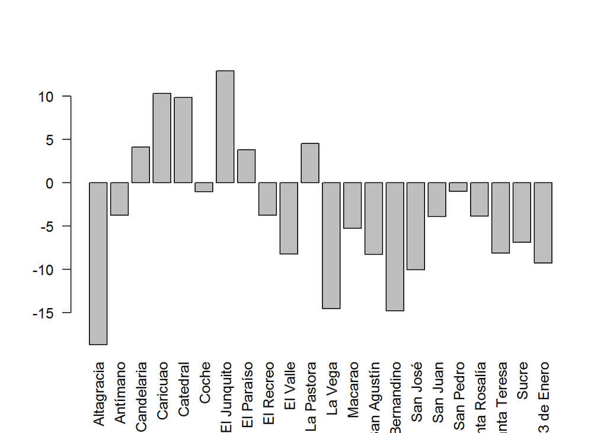

```r
barplot(indice.masculinidad[,4],
        names.arg =indice.masculinidad[,1],
        las=2)
```

Puedo contrastar el comportamiento de los nacidos vivos según el lugar de residencia de la madre y el indice de masculinidad

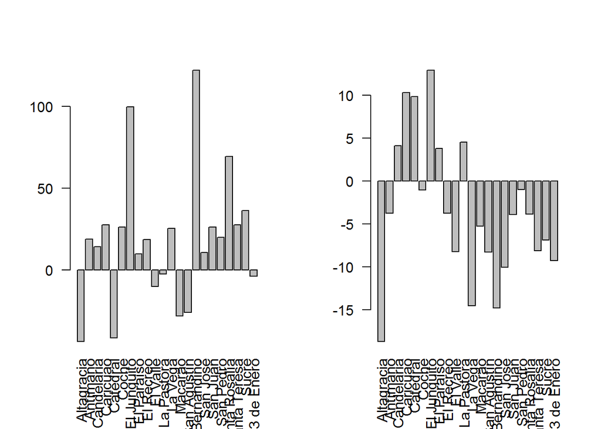

```r
par(mfrow=c(1,2))
barplot(nacimiento_parroquia[,2],
        names.arg = nacimiento_parroquia[,1],
        las=2)

barplot(indice.masculinidad[,4],
        names.arg =indice.masculinidad[,1],
        las=2)
```

En muchas de las parroquias en las que se ha incrementado el número de nacidos vivos, ha decrecido el índice de masculinidad. Menos hombres, pero más nacimientos vivos. Muchos factores podrían explicar esto: migraciones, la violencia, entre otras posibilidades. Lo que sí parece sugerir ambos hecho es la presencia de más mujeres solas con niños.

Creo ahora una función para poder analizar los nacidos vivos según grupos de edades de la madres y parroquia de residencia habitual de la madre.

En primer lugar analizo cuál es el grupo de edad más frecuentes de las madres

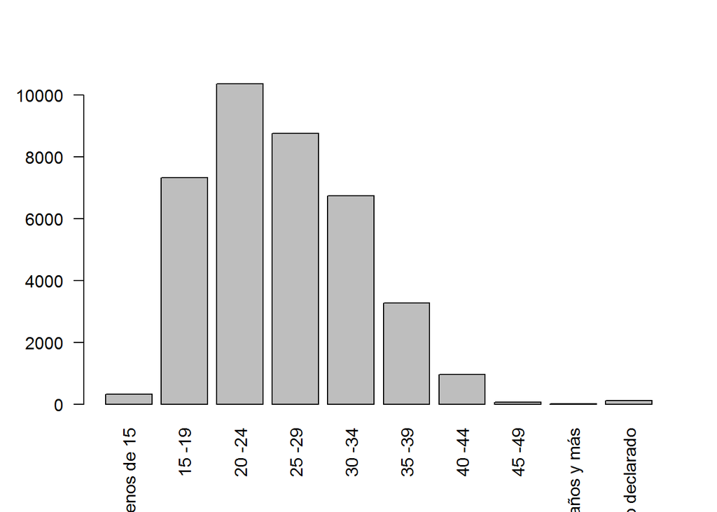

```r
barplot(nacidosVivos$total, names.arg = nacidosVivos$edades,
        las=2)
```

Las mujeres dan a luz generalmente entre los 20-24 años. Veamos ahora qué parroquias tienen una edad menor o mayor a esta. Voy a crear una función que me permita calcular porcentaje. En realidad es una función no muy necesaria, pero nos permite seguir practicando el procedimiento para crear funciones

```r
porcentaje <- function(marco, divisor, dividiendo){
# dado un marco de datos, calcula los porcentajes
# marco: vector o marco de datos que se desea transformar
# divisor: vector o columnas a las que se desea obtener el porcentaje
# dividiendo: vector o columna por la que se desea dividir para obener el porcentaje
# aplicacion:  porcentaje(marco, 3:10, 2)
        df <- as.data.frame(marco)
        proporcion <- df[,divisor]/df[, dividiendo]
        porcentaje <- round(proporcion*100, 1)
        return(porcentaje)
}
```

Pruebo y aplico

```r
nacidosVivos$altagracia/nacidosVivos$total*100
```

```
 [1] 0.6289308 0.9413370 1.2261054 1.4285714 2.0178042 2.3511450 3.1545741
 [8] 0.0000000 0.0000000 0.8620690
```

```r
nacidosVivos$antimano/nacidosVivos$total*100
```

```
 [1] 14.150943 10.450205  9.451632  7.862857  6.557864  6.625954  6.309148
 [8]  9.090909  0.000000 14.655172
```

```r
porcentaje(nacidosVivos, 3:24, 2)
```

| altagracia | antimano | candelaria | caricuao | catedral | coche | junquito | paraiso | recreo | valle | pastora | vega | macarao | s.agustin | s.bernardino | s.jose | s.juan | s.pedro | sta.rosalia | sta.teresa | sucre | veintitres |
| --- | --- | --- | --- | --- | --- | --- | --- | --- | --- | --- | --- | --- | --- | --- | --- | --- | --- | --- | --- | --- | --- |
| 0.6 | 14.2 | 0.3 | 3.8 | 0.3 | 3.1 | 5.0 | 2.2 | 2.5 | 9.1 | 2.8 | 4.7 | 2.2 | 2.2 | 5.0 | 1.3 | 8.2 | 0.9 | 6.0 | 0.6 | 23.6 | 1.3 |
| 0.9 | 10.5 | 1.0 | 5.2 | 0.5 | 3.5 | 5.5 | 2.1 | 2.4 | 8.4 | 2.2 | 7.2 | 3.0 | 1.8 | 4.5 | 1.6 | 6.7 | 1.1 | 4.7 | 0.8 | 23.1 | 3.2 |
| 1.2 | 9.5 | 1.6 | 5.5 | 0.5 | 3.3 | 5.1 | 2.7 | 2.9 | 7.4 | 2.9 | 6.4 | 2.9 | 1.6 | 5.4 | 1.4 | 6.8 | 1.6 | 4.7 | 0.9 | 22.3 | 3.5 |
| 1.4 | 7.9 | 2.1 | 5.4 | 0.5 | 3.2 | 4.8 | 3.3 | 3.1 | 7.2 | 3.0 | 6.2 | 2.8 | 1.6 | 5.9 | 1.5 | 6.6 | 2.1 | 4.7 | 1.1 | 22.5 | 3.3 |
| 2.0 | 6.6 | 2.6 | 6.1 | 0.4 | 2.9 | 4.4 | 3.9 | 3.8 | 7.0 | 3.1 | 6.0 | 2.3 | 1.7 | 5.5 | 1.9 | 6.7 | 2.7 | 5.0 | 1.4 | 21.2 | 2.7 |
| 2.4 | 6.6 | 2.9 | 5.7 | 0.3 | 3.3 | 4.6 | 4.2 | 4.5 | 7.1 | 2.6 | 6.5 | 1.8 | 1.6 | 5.6 | 2.1 | 6.8 | 3.4 | 4.7 | 1.0 | 19.1 | 3.0 |
| 3.2 | 6.3 | 1.5 | 5.9 | 0.1 | 3.3 | 4.4 | 3.9 | 3.9 | 6.7 | 2.5 | 6.8 | 2.3 | 1.9 | 5.6 | 1.3 | 7.8 | 3.4 | 5.0 | 0.5 | 20.2 | 3.6 |
| 0.0 | 9.1 | 6.1 | 6.1 | 0.0 | 4.5 | 4.5 | 6.1 | 0.0 | 7.6 | 0.0 | 6.1 | 3.0 | 4.5 | 6.1 | 3.0 | 4.5 | 1.5 | 4.5 | 1.5 | 18.2 | 3.0 |
| 0.0 | 0.0 | 5.9 | 0.0 | 0.0 | 0.0 | 5.9 | 5.9 | 17.6 | 11.8 | 0.0 | 5.9 | 5.9 | 0.0 | 0.0 | 0.0 | 0.0 | 0.0 | 11.8 | 5.9 | 23.5 | 0.0 |
| 0.9 | 14.7 | 0.0 | 6.9 | 0.0 | 0.0 | 1.7 | 4.3 | 1.7 | 0.0 | 2.6 | 1.7 | 0.0 | 0.0 | 6.0 | 0.0 | 40.5 | 2.6 | 0.9 | 0.9 | 14.7 | 0.0 |

DE cada 100 nacidos en madres menores de 15 años, 14 nacen en Antímano, y 24 en la parroquia Sucre; de cada 100 nacidos en grupos de edades entre 15 y 19 años, 10 nacen en Antìmano y 23 en la parroquia Sucre. Para facilitar la visualización empleo el paquete lattice. Porque voya a crear lo que se llama ‘small.multiples’ En este marco de datos, debemos recordar, hay solo tres variables: grupos de edades, parroquia y porcentaje. Para crear un small.multiple con lattice debo asegurarme que el marco de datos refleje su estructura real.

```r
require(lattice)
# Creo un marco de datos con los porcentajes
nv <- porcentaje(nacidosVivos, 3:24, 2)

head(nv)
```

| altagracia | antimano | candelaria | caricuao | catedral | coche | junquito | paraiso | recreo | valle | pastora | vega | macarao | s.agustin | s.bernardino | s.jose | s.juan | s.pedro | sta.rosalia | sta.teresa | sucre | veintitres |
| --- | --- | --- | --- | --- | --- | --- | --- | --- | --- | --- | --- | --- | --- | --- | --- | --- | --- | --- | --- | --- | --- |
| 0.6 | 14.2 | 0.3 | 3.8 | 0.3 | 3.1 | 5.0 | 2.2 | 2.5 | 9.1 | 2.8 | 4.7 | 2.2 | 2.2 | 5.0 | 1.3 | 8.2 | 0.9 | 6.0 | 0.6 | 23.6 | 1.3 |
| 0.9 | 10.5 | 1.0 | 5.2 | 0.5 | 3.5 | 5.5 | 2.1 | 2.4 | 8.4 | 2.2 | 7.2 | 3.0 | 1.8 | 4.5 | 1.6 | 6.7 | 1.1 | 4.7 | 0.8 | 23.1 | 3.2 |
| 1.2 | 9.5 | 1.6 | 5.5 | 0.5 | 3.3 | 5.1 | 2.7 | 2.9 | 7.4 | 2.9 | 6.4 | 2.9 | 1.6 | 5.4 | 1.4 | 6.8 | 1.6 | 4.7 | 0.9 | 22.3 | 3.5 |
| 1.4 | 7.9 | 2.1 | 5.4 | 0.5 | 3.2 | 4.8 | 3.3 | 3.1 | 7.2 | 3.0 | 6.2 | 2.8 | 1.6 | 5.9 | 1.5 | 6.6 | 2.1 | 4.7 | 1.1 | 22.5 | 3.3 |
| 2.0 | 6.6 | 2.6 | 6.1 | 0.4 | 2.9 | 4.4 | 3.9 | 3.8 | 7.0 | 3.1 | 6.0 | 2.3 | 1.7 | 5.5 | 1.9 | 6.7 | 2.7 | 5.0 | 1.4 | 21.2 | 2.7 |
| 2.4 | 6.6 | 2.9 | 5.7 | 0.3 | 3.3 | 4.6 | 4.2 | 4.5 | 7.1 | 2.6 | 6.5 | 1.8 | 1.6 | 5.6 | 2.1 | 6.8 | 3.4 | 4.7 | 1.0 | 19.1 | 3.0 |

Debo crear ahora una columna con la variable grupos de edad

```r
# necesito colocar la variable parroquia en una
# sola columna,  uso la funcion stack
nvS <-stack(nv)
head(nvS)
```

| values | ind |
| --- | --- |
| 0.6 | altagracia |
| 0.9 | altagracia |
| 1.2 | altagracia |
| 1.4 | altagracia |
| 2.0 | altagracia |
| 2.4 | altagracia |

Debo agregar ahora los grupos de edad. Usaré la función repetir: **rep()**

```r
# ejemplo funcion repetir. Repito: c("A","B"), dos veces
rep(c("A","B"),2)
```

```
[1] "A" "B" "A" "B"
```

```
A

B

A

B
```

```r
# debo repetir los nombres de los grupos  de edades, 9 veces
# en 10 series y agregarlo al marco nvS

nvS$grupos <-rep(nacidosVivos$edades, 9, 10)
#abrevio los nombres de las parroquias
nvS$ind <-abbreviate(nvS$ind)
head(nvS)
```

| values | ind | grupos |
| --- | --- | --- |
| 0.6 | altg | Menos de 15 |
| 0.9 | altg | 15 -19 |
| 1.2 | altg | 20 -24 |
| 1.4 | altg | 25 -29 |
| 2.0 | altg | 30 -34 |
| 2.4 | altg | 35 -39 |

Tengo los ingredientes para hacer el small.muliple

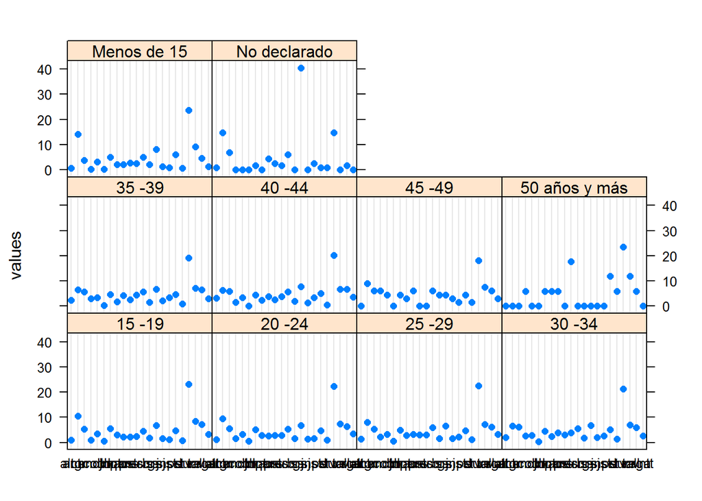

```r
dotplot(values~ind | grupos, data=nvS)
```

Para que los niveles de la variable grupos nos quede como debe ser, debemos decirle a R que grupos es una variable de tipo ordinal. En R eso se donomina factor adicionalmente, podemos abreviar los nombres de las parroquias:

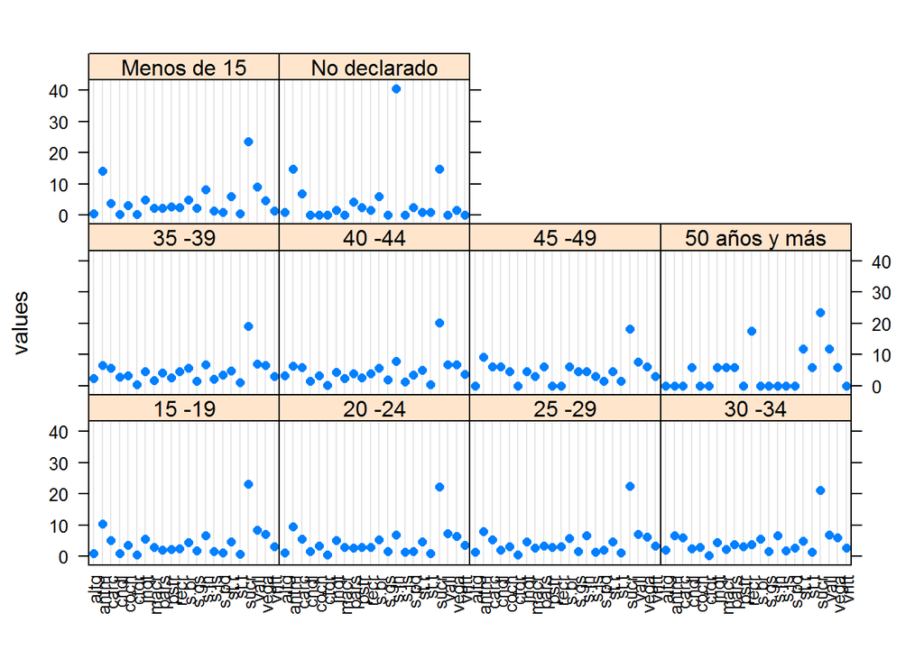

```r
dotplot(values~ind | as.factor(grupos), data=nvS,
        scales= list(x= list(rot=90)))
```

```r
nvS$grupos <-factor(nvS$grupos, order=TRUE,levels=c("Menos de 15",
                                                    "15 -19",
                                                    "20-24",
                                                    "25-29",
                                                    "30 -34",
                                                    "35 -39",
                                                    "40 -44",
                                                    "45 -49",
                                                    "50 años y más",
                                                  "No-declarado"))
```

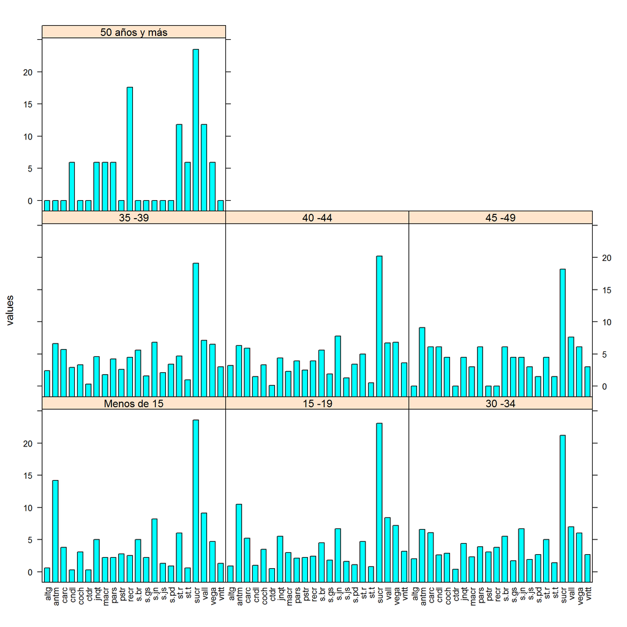

```r
barchart(values~ind | as.factor(grupos), data=nvS,
          scales= list(x= list(rot=90)))
```

Analizo el predominio de adolescentes en las diferentes parroquias

```r
# me desago de la primera fila porque no aporta mucha informacion
md <-nVivosgrupos[2:4,]

# creo un data.frame con los porcentajes
mujeres.Distr<-porcentaje(md, 3:24, 2)
# apilo el data.frme
mDs <-stack(mujeres.Distr)
# agrego la informacion sobre los grupos
mDs$grupos<-rep(md$edades, 2,3)
```

Visualizo la informacion

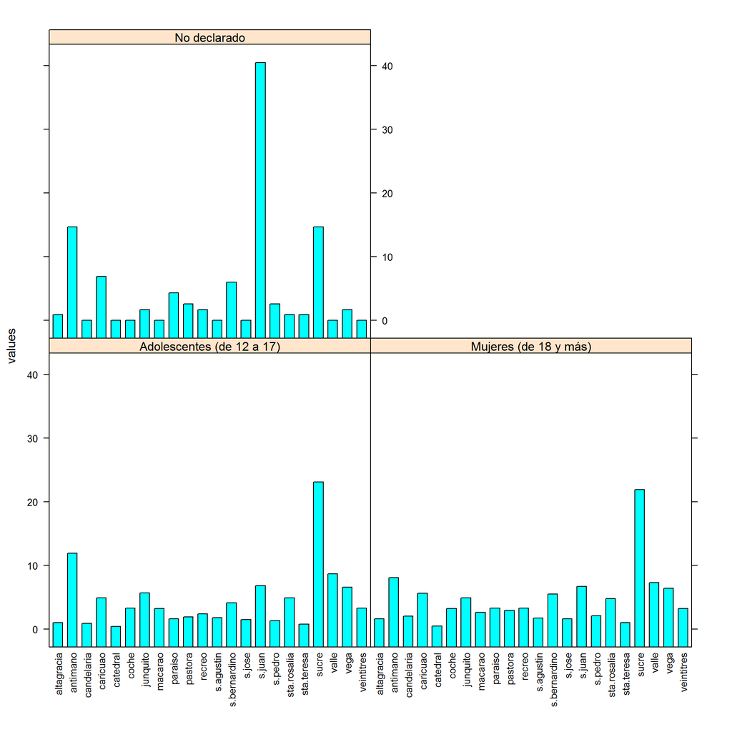

```r
barchart(values~ind | as.factor(grupos), data=mDs,
          scales= list(x= list(rot=90)))
```

Como es de esperarse, hay muchas mas adolescentes en las parroquias Sucre y Antimano

Analizo la distribución de los nacidos vivos por sexo, según grupo de edades de la madre

```r
# creo un data.frame con los porcentajes
mdH<-porcentaje(nvhombres, 3:24, 2)
# apilo el data.frme
mDHp <-stack(mdH)
# agrego la informacion sobre los grupos
mDHp$grupos <-rep(nvhombres$edades, 9, 10)

# mismo procedimiento con las mujeres

# creo un data.frame con los porcentajes
mdM<-porcentaje(nvMujeres, 3:24, 2)
# apilo el data.frme
mDMp <-stack(mdM)
# agrego la informacion sobre los grupos
mDMp$grupos <-rep(nvMujeres$edades, 9, 10)
```

Visualizo la informacion

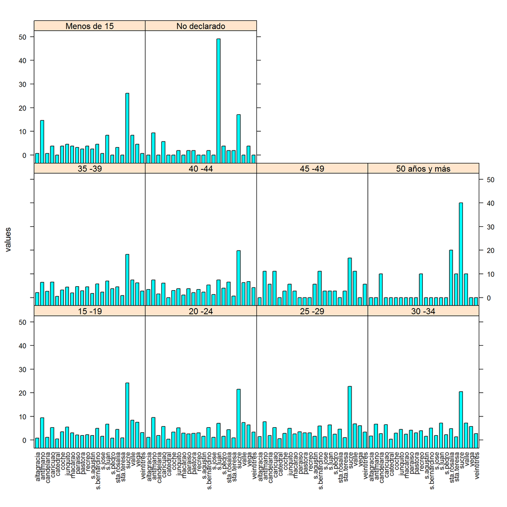

```r
barchart(values~ind | as.factor(grupos), data=mDHp,
          scales= list(x= list(rot=90)))
```

Visualizo la informacion

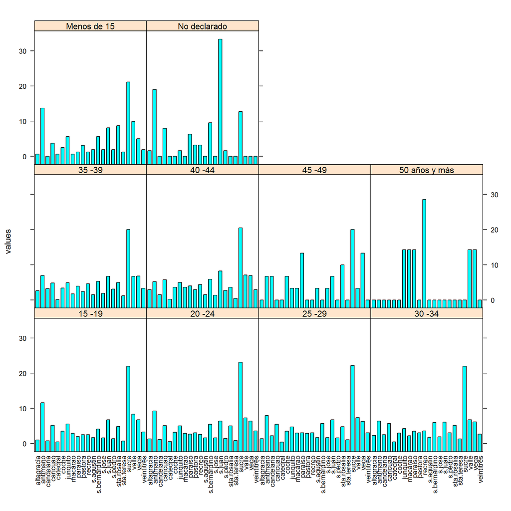

```r
barchart(values~ind | as.factor(grupos), data=mDMp,
          scales= list(x= list(rot=90)))
```

Ahora quiero ver de cada cien niños nacidos vivos en cada parroquia qué porcentaje de niños nacidos aporta cada grupo de edad en cada parroquia

```r
# para obtener los totales de las columnas
colSums(nacidosVivos[,3:24])
```

```
  altagracia     antimano   candelaria     caricuao     catedral
         567         3220          709         2096          170
       coche     junquito      paraiso       recreo        valle
        1227         1872         1174         1202         2814
     pastora         vega      macarao    s.agustin s.bernardino
        1058         2438         1015          638         2038
      s.jose       s.juan      s.pedro  sta.rosalia   sta.teresa
         615         2597          757         1802          380
       sucre   veintitres
        8326         1206
```

Simplemente divido la información del data.frame, de las columnas que me interesan entre el resultado de esta función

```r
nacen<-round(100*nacidosVivos[,3:24]/colSums(nacidosVivos[,3:24]),2)

# apilo
nacenV <-stack(nacen)
# agrego grupos de edad
nacenV$grupos <-rep(nacidosVivos$edades, 9, 10)
```

Visualizo

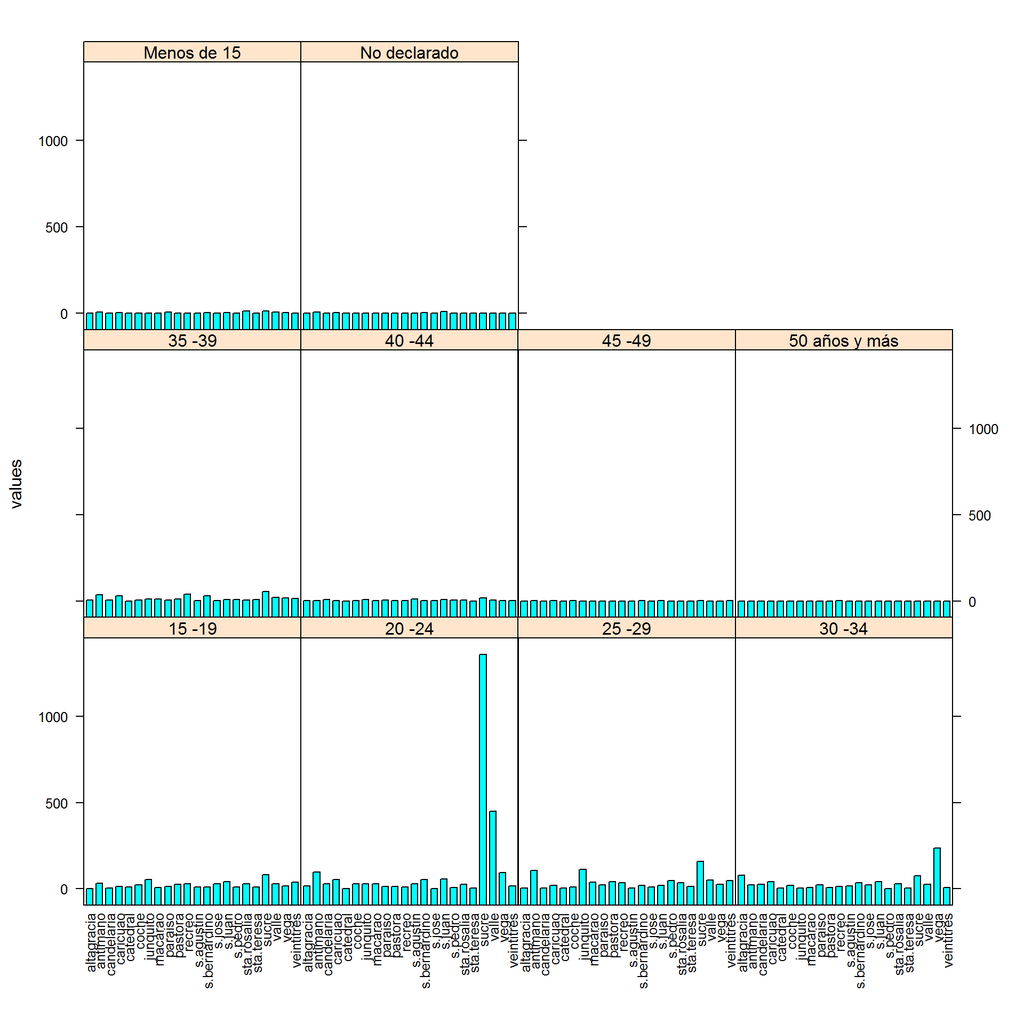

```r
barchart(values~ind | as.factor(grupos), data=nacenV,
          scales= list(x= list(rot=90)))
```

Puedo liberar los paneles de forma tal que cada grupo de edad refleje el rango de valores propios y se puede apreciar mejor la contribución de cada grupo de edad a los nacidos vivos dentro de la parroquia

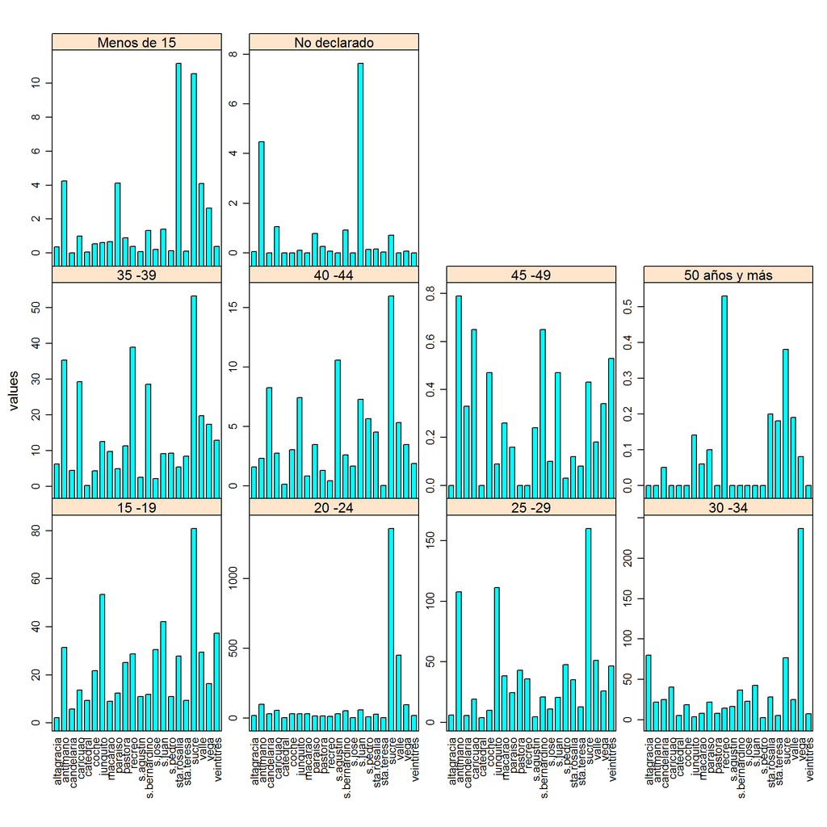

```r
barchart(values~ind | as.factor(grupos), data=nacenV,
          scales= list(x= list(rot=90), y=list(relation="free")))
```

Se considera que los niños nacidos de madres menores de cierta edad están en situación de alto riesgo porque es probable que sufran daños (enfermedad, mortalidad, entre otros). La escala es:

- Alto riesgo: madres menores de 20 años
- Riesgo intermedio: madres mayores de 34 años
- Bajo riesgo: madres entre 20 y 34 años

Al analizar la situación dentro de cada parroquia, por el número de nacidos vivo y la edad de la madre, la parroquia Sucre presenta un alto riegos.

Examino los nacidos vivos según la situación conyugal de las madres en las diferentes parroquias. Se considera que un niño nacido de una mujer sin pareja presenta mayores riesgos que un niño nacido de una madre con pareja.

Examino de cada 100 nacidos vivos cuantos de esos niños están en qué parroquia y cuál es la situación conyugal de la madre

```r
conyugal <- porcentaje(dinamica3, 3:9, 2)
conyugalS <-stack(conyugal)
table(conyugalS$ind)
```

```
      Casada   Divorciada No declarado     Separada      Soltera
          22           22           22           22           22
       Unida        Viuda
          22           22
```

```r
conyugalS$parroquia <-rep(dinamica3$parroquia, 22,22)
```

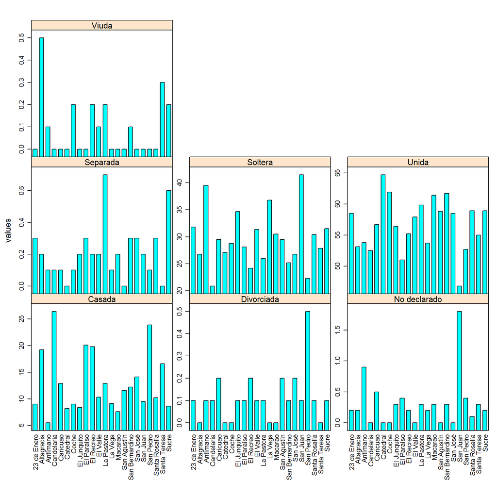

```r
barchart(values~parroquia | ind, data=conyugalS,
          scales= list(x= list(rot=90), y=list(relation="free")))
```

Analizo ahora la defunciones

```r
defunV<-data.frame(parroquia =defunciones[,1],
                   variacion=variacion1(defunciones$`2012`, defunciones$`2001`))
```

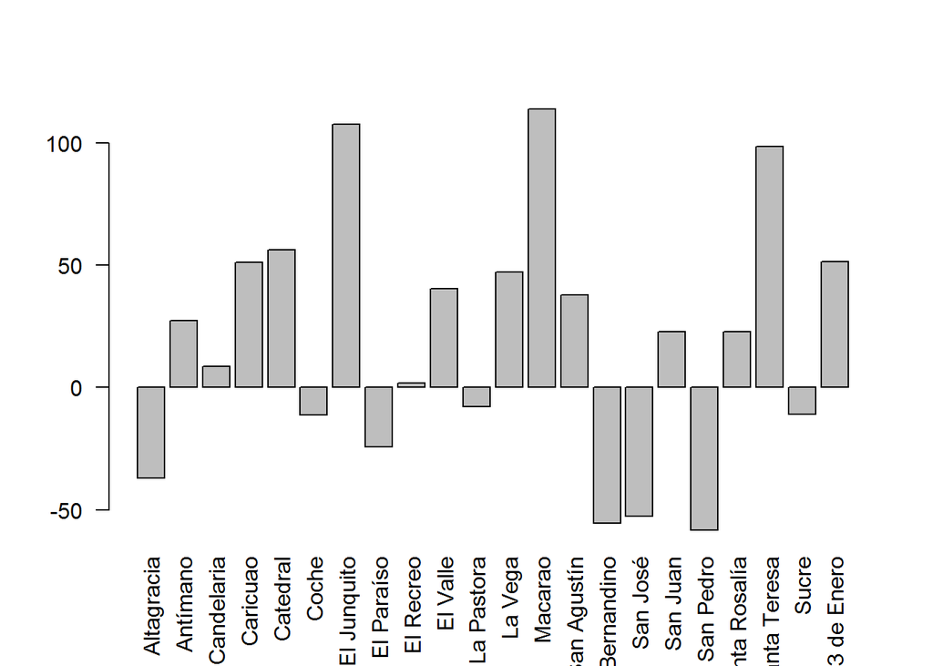

```r
barplot(defunV$variacion, names.arg = defunV$parroquia,
        las=2)
```

En qué grupos de edades se producen las mayores defunciones

```r
dGrupos<-defuncionesEdades[,2]/colSums(defuncionesEdades[,2])*100
```

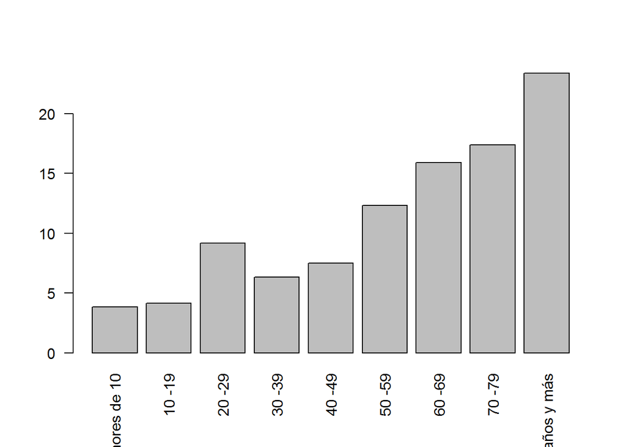

```r
barplot(dGrupos$total, names.arg = defuncionesEdades$edades,
        las=2)
```

Como se observa este comportamiento en las diferentes parroquias

```r
dParroquia <- porcentaje(defuncionesEdades, 3:24, 2)
dParroquiaS <-stack(dParroquia)
table(conyugalS$ind)
```

```
      Casada   Divorciada No declarado     Separada      Soltera
          22           22           22           22           22
       Unida        Viuda
          22           22
```

```r
dParroquiaS$grupos <-rep(defuncionesEdades$edades, 22,9)
```

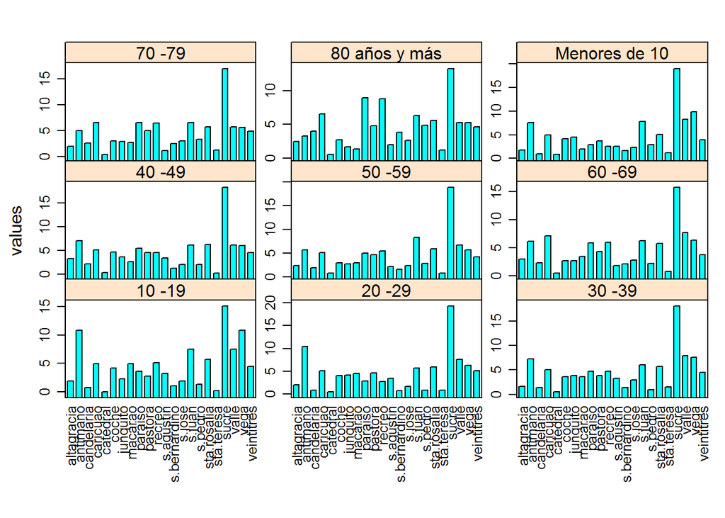

```r
barchart(values~ind | grupos, data=dParroquiaS,
          scales= list(x= list(rot=90), y=list(relation="free")))
```

En las defunciones por sexo, quiero ver en qué parroquias mueren más hombres que en mujeres. El indice de masculinidad en las defunciones

```r
a <- seq(2, 25, by=2)
b<- seq(1,25, by=2)
b<-b[-1]

def.masc<-masculinidad(defuncionesSexos[,a], defuncionesSexos[,b])
names(def.masc)<-2001:2012
defMasc <- stack(def.masc)
defMasc$parroquia <-rep(defuncionesSexos$parroquia, 22,22)
```

Visualizo

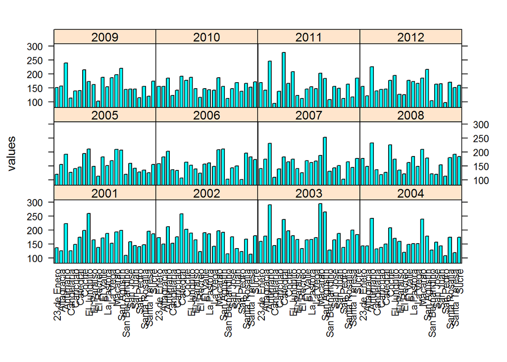

```r
barchart(values~parroquia | ind, data=defMasc,
          scales= list(x= list(rot=90)))
```

Otra perspectiva

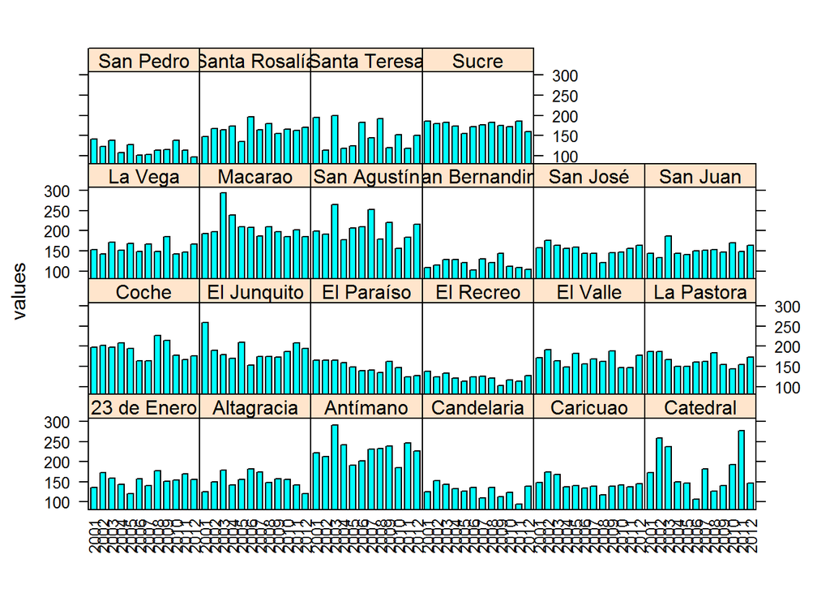

```r
barchart(values~ind | parroquia, data=defMasc,
          scales= list(x= list(rot=90)))
```

En qué parroquias ocurren las mayores muertes en menores de 5 años

```r
names(muertesCinco)<-c("parroquias", 2001:2012)

mCinco <-100*muertesCinco[, 2:13]/colSums(muertesCinco[, 2:13])
mCincos <-stack(round(mCinco,2))
mCincos$parroquias <-rep(muertesCinco$parroquias, 22,22)
```

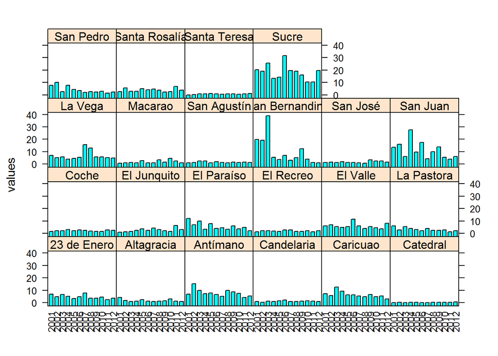

```r
barchart(values~ind | parroquias, data=mCincos,
          scales= list(x= list(rot=90)))
```

La evolución de los matrimonios por parroquia

```r
matrimonios$`2001` <-gsub("-", "NA", matrimonios$`2001`)

matrimonios$`2001` <- as.numeric(matrimonios$`2001`)
casorios <-matrimonios[, 2:13]/colSums(matrimonios[, 2:13])*100

kasorios <-stack(round(casorios,2))

kasorios$parroquias <-rep(matrimonios$parroquias, 22,22)
```

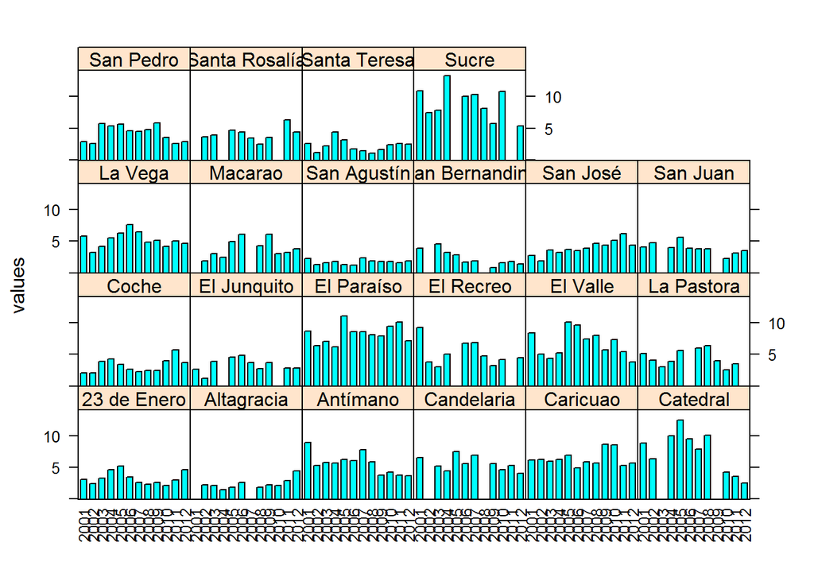

```r
barchart(values~ind | parroquias, data=kasorios,
          scales= list(x= list(rot=90)))
```

Veamos el indice de envejecimiento por parroquia

$$indice\ envejecimiento\ =\frac{\left(personas\ 65\ y\ mas\right)}{personas\ <\ 15}\cdot100$$

En este momento no tenemos el numero de personas menores de 15 años, por tanto, solo graficaremos el porcentaje de personas adultas por parroquia

```r
lasEdades <-porcentaje(edadesParroquia, 3:24, 2)
edadS <-stack(lasEdades)
edadS$grupos <-rep(edadesParroquia$edades, 22, 4)
```

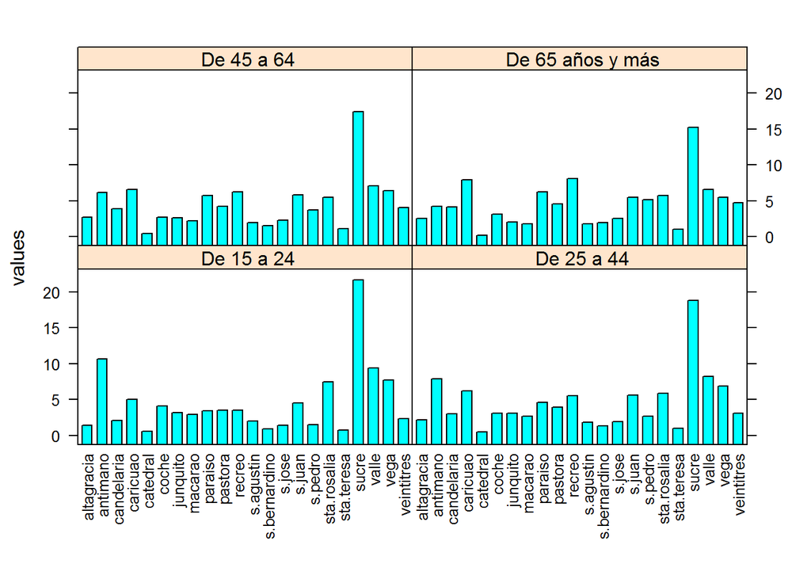

```r
barchart(values~ind | grupos, data=edadS,
          scales= list(x= list(rot=90)))
```

No es un gráfico muy interesante pues es obvio que la densidad poblacional nos influye en los resultado. Haré un indice provicional de los mayores de 65 años con respecto a los otros tres grupos de edad

```r
mayores <-edadesParroquia[4, 3:24]
noMayores <- colSums(edadesParroquia[1:3, 3:24])

relacion <-mayores/noMayores *100
```

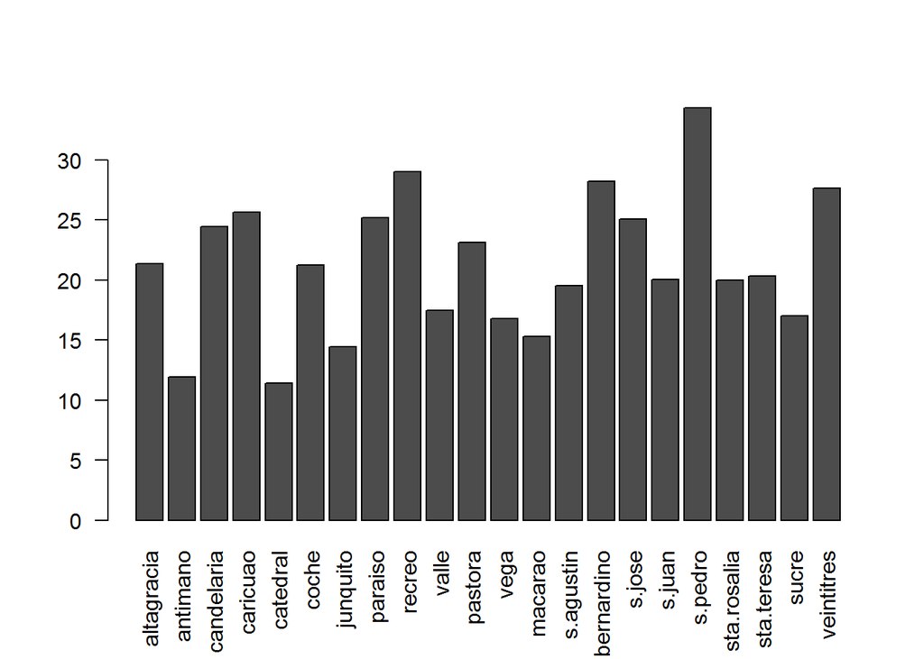

```r
barplot(as.matrix(relacion), las=2)
```

numero de hijos por hogar

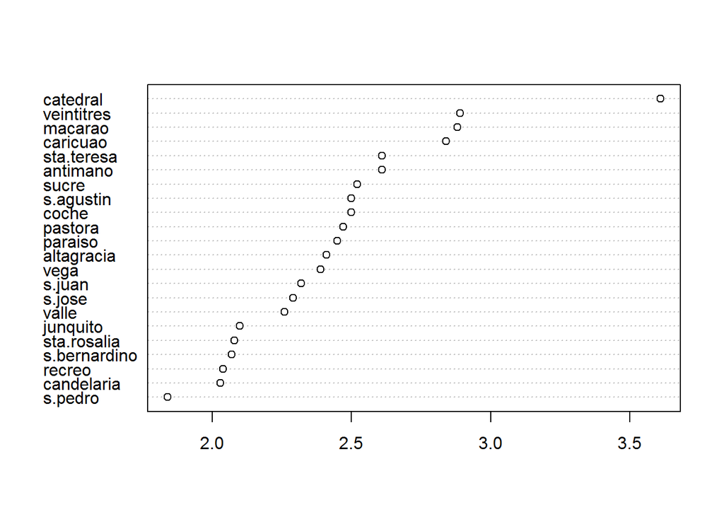

```r
Hh<-stack(hijosHogar[, 3:24])
Hh <- Hh[order(Hh$values),]
dotchart(Hh$values, labels=Hh$ind)
```

Edad de la madre al tener el primer hijo

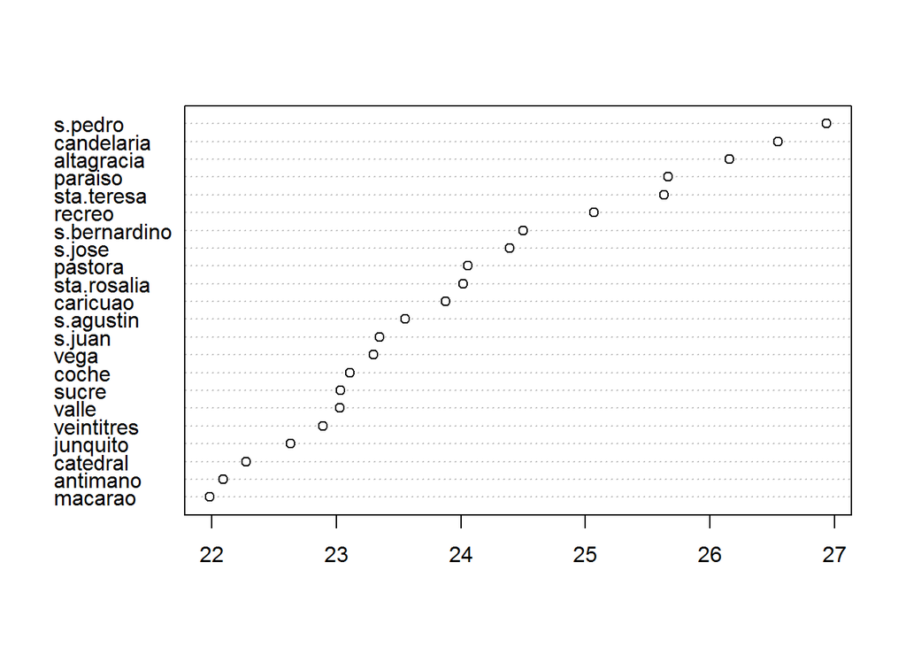

```r
mph <-stack(madrePrimerHijo[, 3:24])
mph <- mph[order(mph$values),]
dotchart(mph$values, labels=mph$ind)
```

Edad promedio al morir

```r
epm <-stack(edadPromedioMuerte[2:3, 3:24])
epm$sexo <-rep(c("H", "M"), 22, 2)
epm$color<-ifelse(epm$sexo =="H", "darkgreen", "darkred")
epm <- epm[order(epm$values),]
```

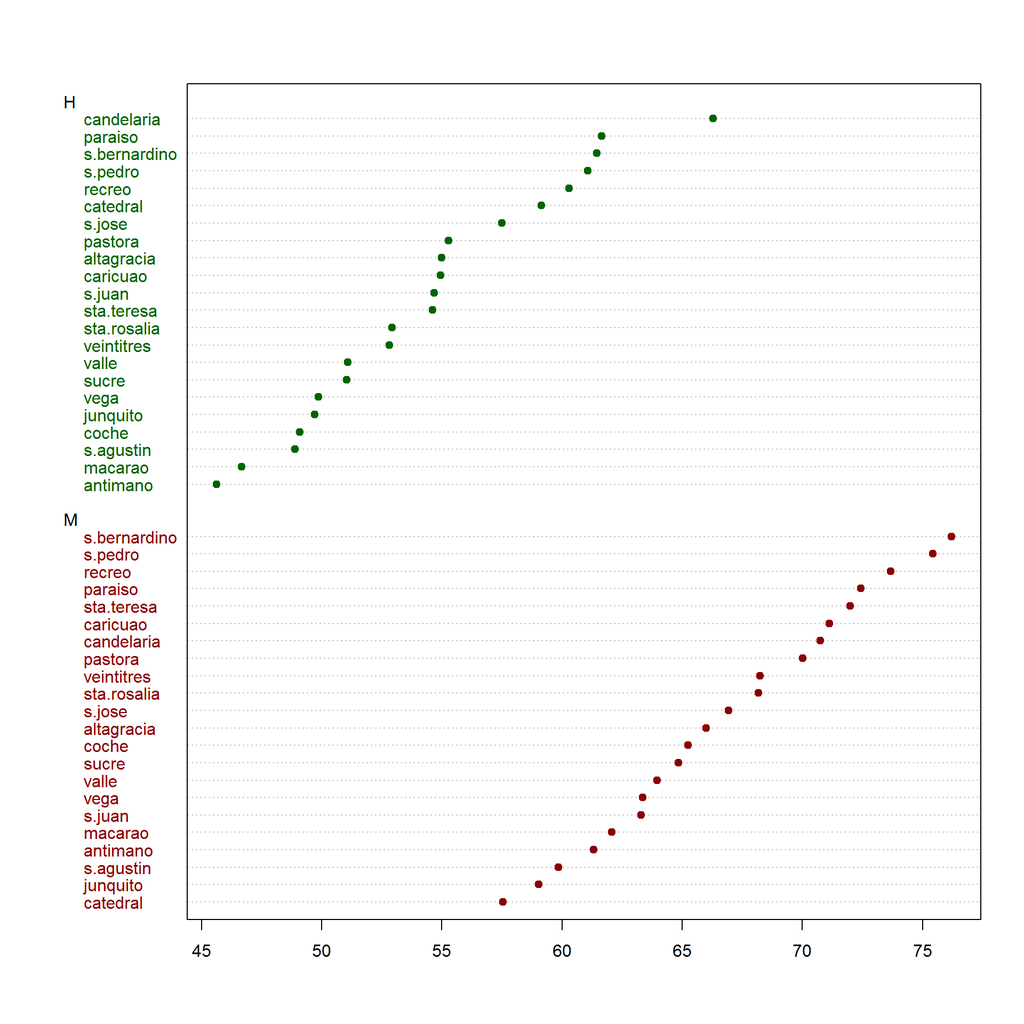

```r
dotchart(epm$values, labels=epm$ind, pch=19,
         color=epm$color,
         groups=factor(epm$sexo))
```